# RUC Practical AI Final Project: Traffic Sign Classification Using Deep Learning with Adversarial Robustness

**Introduction**: An essential component of intelligent transportation systems and autonomous driving is the detection of traffic signs. As AI is used in transportation more and more, it is critical to make sure that categorisation models are safe and dependable. This project's major goal is to create a traffic sign recognition model that is not just highly effective at recognising signs in everyday situations but also resilient to adversarial attacks, which are intentional changes meant to deceive models. This research attempts to create a model that can function dependably in real-world situations, especially when subjected to adversarial effects, by combining convolutional neural networks (CNNs), preprocessing modifications, and adversarial training. This work is important because it has the potential to improve the effectiveness and safety of AI-powered transportation systems.

**Problem Addressed**: As per the Ai incident database, from 2015 to 2024, there have been around 28 accidents reported where people were driving self driving cars or the self driving cars were involved. Today we living in a world which is moving towards automations at a rapid speed and soon, the day will come when it will all be autnomous. Which gives us many more reasons to work towards making these models better. Self driving cars require a lot of automation.Among other things, we need to make sure that our automation systems, are able to recognise the traffic signs properly. The security of driverless cars and intelligent transportation systems is seriously threatened by adversarial flaws in traffic sign recognition models. Vehicles may misinterpret traffic signs due to adversarial instances designed to deceive AI algorithms, which could result in accidents or infractions of traffic laws. Advanced defensive techniques are required since traditional models are not resilient enough to withstand such attacks. In order to guarantee the dependability of AI systems in practical applications, this project tackles the urgent need for robust traffic sign classifiers that can retain accuracy even in hostile environments.

**Motivation**: The increasing dependence on AI systems in transportation and the urgent need to protect them from hostile threats are the driving forces behind this effort. For safe operation, autonomous cars, driver aid programs, and traffic monitoring systems rely on precise traffic sign recognition. By improving road safety, reducing the likelihood of misclassification-related incidents, and promoting confidence in AI-driven technology, the project's success would have a direct positive impact on society. Our main motivation was to use our learnings to solve a real world problem. We as engineers love to create things that makes the world a safer and a better place. We know that this is a small contribution but drop by drop fills a pitcher. We hope that with our contributions, if we can avoid atleast one accident, we will belive that we were successful in our work.

**Previous Work**: Previous research has investigated adversarial attacks such as FGSM and PGD, as well as CNN-based traffic sign recognition. But many don't have strong defences. In order to further increase robustness, this effort has used preprocessing techniques in conjunction with adversarial training, a well-known strategy for boosting resilience.

**Project Schedule and Budget**: PyTorch and other open-source tools were used to complete this project without incurring any major expenses. Over the course of two weeks, the timeline covered data preprocessing, model construction, adversarial training, and evaluation. Naman and I each integrated our models into a traffic sign recognition system in order to productionize, with testing and model deployment serving as milestones.

The technical methodology guarantees a thorough assessment of model performance and robustness by methodically handling both clean and adversarial scenarios.

**Future Work**: Future research will examine more attack techniques (such as CW and DeepFool), integrate sophisticated defensive techniques like adversarial detection, and scale the system for real-time applications. We'll also look into transferability between datasets and geographical areas.

**Discussion**: This study shows how preprocessing and adversarial training may be used to build reliable traffic sign classifiers. The results highlight how crucial it is to incorporate defensive techniques into AI systems in order to guarantee dependability and safety in crucial applications such as autonomous driving.

## Imports

Importing the necessary libraires and dependencies!

```python
import os, sys

sys.path.append(os.path.abspath("../finalproject"))
import pandas as pd


from PIL import Image
import matplotlib.pyplot as plt
import random
import torch


import torchvision.transforms as transforms
import torchvision.datasets as datasets
import numpy as np
from torch.utils.data import DataLoader
from torch.utils.data import Dataset
import torch.nn as nn
import torch.optim as optim


from torchvision.transforms.functional import to_pil_image, to_tensor
from torchvision.datasets import ImageFolder
from torch.utils.data import random_split
import plots
import models
import attack
```

## Reading Data

Reading data from respective data paths!

```python
# Paths
data_folder = "../Data/DATA"
labels_csv = "../Data/labels.csv"

# Load the labels
labels_df = pd.read_csv(labels_csv)
labels_dict = dict(zip(labels_df["ClassId"], labels_df["Name"]))
```

```python
labels_df.head()
```

|  | ClassId | Name |
| --- | --- | --- |
| 0 | 0 | Speed limit (5km/h) |
| 1 | 1 | Speed limit (15km/h) |
| 2 | 2 | Speed limit (30km/h) |
| 3 | 3 | Speed limit (40km/h) |
| 4 | 4 | Speed limit (50km/h) |

Now let's start by preparing two separate lists for images and labels.

```python
# Prepare lists for images and labels
image_paths = []
image_labels = []

# Iterate through subfolders and load images
for folder_name in os.listdir(data_folder):
    folder_path = os.path.join(data_folder, folder_name)
    if os.path.isdir(folder_path):
        label = labels_dict.get(
            int(folder_name)
        )  # converting it into integer to access the item of the label dictionary
        if label is not None:
            for image_name in os.listdir(folder_path):
                image_path = os.path.join(folder_path, image_name)
                if os.path.isfile(image_path):
                    image_paths.append(image_path)
                    image_labels.append(label)
```

```python
len(image_paths), len(image_labels)
```

```
(4170, 4170)
```

Now let's visualize what our dataset looks like to have an idea about further steps!

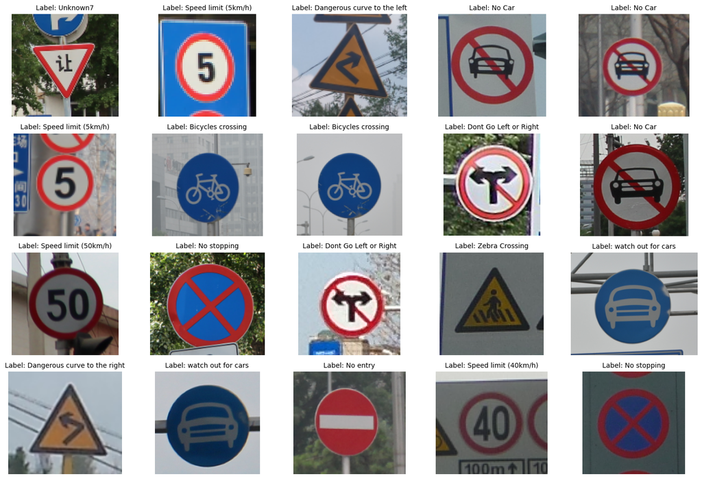

```python
plots.plot_images(image_paths, image_labels, num_images=20)
```

### Loading the Data

Leveraging **PyTorch's** random number generator for splitting the dataset into - Training and Testing sets, while creating **dataloaders** to efficiently feed batches of data during training and evaluation.

```python
torch.manual_seed(42)
transform = transforms.Compose(
    [
        transforms.Resize((64, 64)),
        transforms.ToTensor(),
        transforms.Normalize([0.5], [0.5]),
    ]
)

dataset = ImageFolder(root=data_folder, transform=transform)

# Split sizes

train_size = int(0.8 * len(dataset))  # 80% for training
test_size = len(dataset) - train_size  # Remaining 20% for testing

# Randomly split dataset
train_dataset, test_dataset = random_split(dataset, [train_size, test_size])

# Dataloaders for training and testing
train_dataloader = DataLoader(train_dataset, batch_size=64, shuffle=True)
test_dataloader = DataLoader(test_dataset, batch_size=64, shuffle=False)


print(f"Training set size: {len(train_dataset)}")
print(f"Testing set size: {len(test_dataset)}")
```

```
Training set size: 3336
Testing set size: 834
```

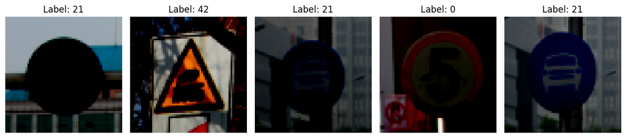

```python
# Visualize Training Samples
plots.visualize_samples(train_dataset, num_samples=5)
```

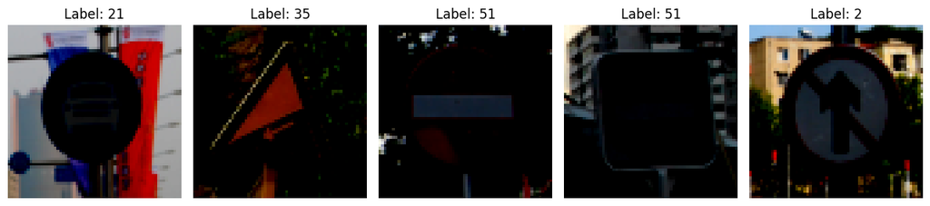

```python
# Visualize Testing Samples
plots.visualize_samples(test_dataset, num_samples=5)
```

# Kenil's Model

## Creating Attacking Adversarial Model

Now let's add transformations to the images in our dataset, but why exactly? Adding transformations such as **"Gaussian Noise"**, **"Distortion"**, **"Random Rotation"** helps in augmenting the images which helps in the pre-processing phase for enhanced results.

```python
from attack import GaussianNoise, Distortion
```

A **Generative Adversarial Network** (**GAN**) is a type of machine learning model used to generate new data instances that resemble the training data. It consists of two neural networks, a generator and a discriminator, that work in opposition (adversarially) to each other.

```python
from attack import Generator, Discriminator
```

Since this is an attacking model, adding perturbations would be a great way to go about and see how the model responds to such adversarial cases. This is what **Fast Gradient Sign Method (FGSM)** exactly does, it generates adversarial examples by adding small perturbations to input data to fool a machine learning model.

```python
from attack import fgsm_attack
```

### Training the Attacking Model

Let's train the attacking model: Let's programme the **Generator** to Create Fake Images (from noise) and **Discriminator** to distinguish between fake vs real images. Looping through the dataset for **20 epochs** for better accuracy!

```python
device = torch.device("cuda" if torch.cuda.is_available() else "cpu")

# Initialize attacking model
z_dim = 100
generator = Generator(z_dim).to(device)
discriminator = Discriminator().to(device)


# Optimizers and loss function

optimizer_G = optim.Adam(generator.parameters(), lr=0.0002, betas=(0.5, 0.999))

optimizer_D = optim.Adam(
    discriminator.parameters(), lr=0.00005, betas=(0.5, 0.999)
)


adversarial_loss = nn.BCELoss()


# Training loop

epochs = 20

for epoch in range(epochs):

    for real_imgs, _ in train_dataloader:
        real_imgs = real_imgs.to(device)

        batch_size = real_imgs.size(0)

        valid = torch.full(
            (batch_size, 1), 0.9, device=device
        )  # Real label smoothing

        fake = torch.full(
            (batch_size, 1), 0.1, device=device
        )  # Fake label smoothing

        # Train Discriminator

        optimizer_D.zero_grad()

        z = torch.randn(batch_size, z_dim, device=device)

        fake_imgs = generator(z)

        perturbed_fake_imgs = fgsm_attack(fake_imgs, fake, discriminator)

        real_loss = adversarial_loss(discriminator(real_imgs), valid)

        fake_loss = adversarial_loss(
            discriminator(perturbed_fake_imgs.detach()), fake
        )

        d_loss = (real_loss + fake_loss) / 2

        d_loss.backward()

        optimizer_D.step()

        # Train Generator

        optimizer_G.zero_grad()

        g_loss = adversarial_loss(discriminator(perturbed_fake_imgs), valid)

        g_loss.backward()

        optimizer_G.step()

    print(
        f"[Epoch {epoch}/{epochs}] [D loss: {d_loss.item():.4f}] [G loss: {g_loss.item():.4f}]"
    )
```

```
[Epoch 0/20] [D loss: 0.3430] [G loss: 2.1826]
[Epoch 1/20] [D loss: 0.3320] [G loss: 2.1815]
[Epoch 2/20] [D loss: 0.3284] [G loss: 2.2586]
[Epoch 3/20] [D loss: 0.3299] [G loss: 2.0746]
[Epoch 4/20] [D loss: 0.3265] [G loss: 2.1031]
[Epoch 5/20] [D loss: 0.3272] [G loss: 2.0576]
[Epoch 6/20] [D loss: 0.3271] [G loss: 2.2463]
[Epoch 7/20] [D loss: 0.3259] [G loss: 2.0549]
[Epoch 8/20] [D loss: 0.3285] [G loss: 2.0799]
[Epoch 9/20] [D loss: 0.3258] [G loss: 2.0705]
[Epoch 10/20] [D loss: 0.3261] [G loss: 2.0872]
[Epoch 11/20] [D loss: 0.3259] [G loss: 2.0729]
[Epoch 12/20] [D loss: 0.3260] [G loss: 2.0426]
[Epoch 13/20] [D loss: 0.3270] [G loss: 1.9671]
[Epoch 14/20] [D loss: 0.3254] [G loss: 2.1180]
[Epoch 15/20] [D loss: 0.3258] [G loss: 2.0640]
[Epoch 16/20] [D loss: 0.3262] [G loss: 2.1390]
[Epoch 17/20] [D loss: 0.3258] [G loss: 2.2104]
[Epoch 18/20] [D loss: 0.3260] [G loss: 2.0977]
[Epoch 19/20] [D loss: 0.3255] [G loss: 2.1962]
```

## Creating a NN (classification model)

Creating a Neural Network Classification Model to evaluate the performance on clean and adversarial data.

```python
# Initialize the classifier
num_classes = len(labels_dict)
device = torch.device("cuda" if torch.cuda.is_available() else "cpu")
classifier = models.Classifier(num_classes).to(device)

# Optimizer and Loss Function
optimizer = optim.Adam(classifier.parameters(), lr=0.001, weight_decay=1e-4)
criterion = nn.CrossEntropyLoss()
```

```python
# Training the Classifier
epochs = 20
for epoch in range(epochs):
    classifier.train()
    epoch_loss = 0
    correct = 0
    total = 0
    for images, labels in train_dataloader:
        images, labels = images.to(device), labels.to(device)

        # Forward pass
        outputs = classifier(images)
        loss = criterion(outputs, labels)

        # Backward pass
        optimizer.zero_grad()
        loss.backward()
        optimizer.step()

        epoch_loss += loss.item()
        _, predicted = outputs.max(1)
        correct += predicted.eq(labels).sum().item()
        total += labels.size(0)

    print(
        f"Epoch {epoch+1}/{epochs}, Loss: {epoch_loss:.4f}, Accuracy: {correct/total:.4f}"
    )
```

[output not shown]

## Evaluating the Classification Model

Evaluating the accuracy for clean data!

```python
# Evaluate Classifier on Clean Data
from evaluation import evaluate_model
```

```python
clean_accuracy = evaluate_model(classifier, test_dataloader)
print(f"Clean Data Accuracy: {clean_accuracy:.4f}")
```

```
Clean Data Accuracy: 0.9904
```

Evaluating the accuracy on adversarial data!

```python
# Defining Hyperparameters
epsilon = 0.08
```

```python
# Evaluate Classifier on Adversarial Data
from evaluation import evaluate_adversarial
```

```python
adversarial_accuracy_before = evaluate_adversarial(
    classifier, generator, test_dataloader, fgsm_attack, epsilon
)
print(
    f"Adversarial Accuracy After Adding GAN and Noise: {adversarial_accuracy_before:.4f}"
)
```

```
Adversarial Accuracy After Adding GAN and Noise: 0.2854
```

Let's visualize all that we coded so far to have a better picture of what all this looks like!

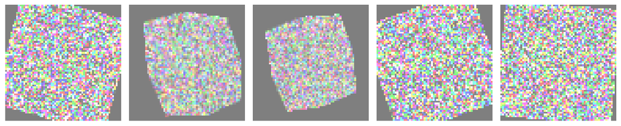

```python
# Visualziing Images generated by the Attacking model
plots.visualize_generated_images(generator, num_images=5, z_dim=100)
```

## Defense Model

```python
# Define defensive transformations
defensive_transforms = transforms.Compose(
    [
        transforms.RandomRotation(degrees=20),  # Random rotation
        transforms.RandomPerspective(
            distortion_scale=0.5, p=0.5
        ),  # Perspective distortion
        transforms.ColorJitter(
            brightness=0.2, contrast=0.2, saturation=0.2
        ),  # Color jitter
        transforms.GaussianBlur(kernel_size=(5, 5)),  # Gaussian blur
    ]
)
```

```python
torch.manual_seed(42)
dataset2 = ImageFolder(root=data_folder, transform=transform)

# Split sizes
train_size = int(0.8 * len(dataset2))  # 80% for training
rem_size = len(dataset) - train_size  # Remaining 20% for testing

# Randomly split dataset
train_dataset2, _ = random_split(dataset2, [train_size, rem_size])
# Dataloaders for training and testing
train_dataloader2 = DataLoader(train_dataset2, batch_size=64, shuffle=True)
print(f"Training set size: {len(train_dataset)}")
```

```
Training set size: 3336
```

```python
epsilon = 0.03
alpha = 0.01
epochs = 20
```

The **Projected Gradient Descent** (**PGD**) attack applies multiple small perturbations to the input over several iterations, while projecting the perturbed input back into a valid range if necessary.

```python
from defense import pgd_attack
```

Training the Defense Model utilizing defensive techniques, looping it for **20** Epochs.

```python
# Training the model on defensive techniques
for epoch in range(epochs):
    classifier.train()
    total_loss = 0
    correct = 0
    total = 0

    for images, labels in train_dataloader:
        images, labels = images.to(device), labels.to(device)

        # Generate adversarial examples
        adversarial_images = pgd_attack(
            classifier, images, labels, epsilon, alpha, attack_epochs=10
        )

        # Combine clean and adversarial images
        combined_images = torch.cat([images, adversarial_images])
        combined_labels = torch.cat([labels, labels])

        # Forward pass
        outputs = classifier(combined_images)
        loss = criterion(outputs, combined_labels)

        # Backward pass and optimization
        optimizer.zero_grad()
        loss.backward()
        optimizer.step()

        total_loss += loss.item()
        _, predicted = outputs.max(1)
        correct += predicted.eq(combined_labels).sum().item()
        total += combined_labels.size(0)

    accuracy = correct / total * 100
    print(
        f"Epoch [{epoch+1}/{epochs}], Loss: {total_loss:.4f}, Accuracy: {accuracy:.2f}%"
    )
```

```
Epoch [1/20], Loss: 52.7819, Accuracy: 74.12%
Epoch [2/20], Loss: 28.8181, Accuracy: 84.52%
Epoch [3/20], Loss: 19.2249, Accuracy: 89.72%
Epoch [4/20], Loss: 15.6902, Accuracy: 91.76%
Epoch [5/20], Loss: 13.5854, Accuracy: 92.91%
Epoch [6/20], Loss: 12.3430, Accuracy: 93.44%
Epoch [7/20], Loss: 11.8680, Accuracy: 93.84%
Epoch [8/20], Loss: 10.9602, Accuracy: 94.18%
Epoch [9/20], Loss: 10.8536, Accuracy: 94.06%
Epoch [10/20], Loss: 12.7352, Accuracy: 93.44%
Epoch [11/20], Loss: 12.8106, Accuracy: 92.79%
Epoch [12/20], Loss: 12.0934, Accuracy: 93.30%
Epoch [13/20], Loss: 13.8456, Accuracy: 92.60%
Epoch [14/20], Loss: 10.4611, Accuracy: 94.15%
Epoch [15/20], Loss: 9.4657, Accuracy: 94.69%
Epoch [16/20], Loss: 8.8833, Accuracy: 95.02%
Epoch [17/20], Loss: 8.4470, Accuracy: 95.16%
Epoch [18/20], Loss: 8.6944, Accuracy: 95.07%
Epoch [19/20], Loss: 8.6894, Accuracy: 95.07%
Epoch [20/20], Loss: 8.8262, Accuracy: 95.07%
```

### Evaluating the Defense Model

Evaluating model's accuracy on clean data

```python
# Evaluate Classifier on Clean Data
def evaluate_model(model, dataloader):
    model.eval()
    correct = 0
    total = 0
    with torch.no_grad():
        for images, labels in dataloader:
            images, labels = images.to(device), labels.to(device)
            outputs = model(images)
            _, predicted = outputs.max(1)
            correct += predicted.eq(labels).sum().item()
            total += labels.size(0)
    return correct / total
```

```python
clean_accuracy = evaluate_model(classifier, test_dataloader)
print(f"Clean Data Accuracy: {clean_accuracy:.4f}")
```

```
Clean Data Accuracy: 0.9868
```

Evaluating model's accuracy on adversarial data

```python
adversarial_accuracy_before = evaluate_adversarial(
    classifier, generator, test_dataloader, fgsm_attack, epsilon
)
print(
    f"Adversarial Accuracy After Adding GAN and Noise: {adversarial_accuracy_before:.4f}"
)
```

```
Adversarial Accuracy After Adding GAN and Noise: 0.8993
```

# Naman's Model

Using PyTorch's Random Number Generation function to split datasets into - Training & Testing data, while passing it through dataloader.

```python
torch.manual_seed(42)
transform = transforms.Compose(
    [
        transforms.Resize((64, 64)),
        transforms.ToTensor(),
        transforms.Normalize([0.5], [0.5]),
    ]
)
dataset = ImageFolder(root=data_folder, transform=transform)

# Train-Test Split
train_size = int(0.8 * len(dataset))  # 80% for training
test_size = len(dataset) - train_size  # Remaining 20% for testing
train_dataset, test_dataset = random_split(dataset, [train_size, test_size])

# Dataloaders for training and testing
train_dataloader = DataLoader(train_dataset, batch_size=64, shuffle=True)
test_dataloader = DataLoader(test_dataset, batch_size=64, shuffle=False)
print(f"Training set size: {len(train_dataset)}")
print(f"Testing set size: {len(test_dataset)}")
```

```
Training set size: 3336
Testing set size: 834
```

## Creating Neural Network Classification Model

Creating a basic fundamental **Simple Classifier** (Neural Network) which later gets optimized by **Adam** function.

```python
# Initialize the model
device = torch.device("cuda" if torch.cuda.is_available() else "cpu")
num_classes = len(dataset.classes)
naman_model = models.SimpleClassifier(num_classes).to(device)

# Define the loss function and optimizer
criterion = nn.CrossEntropyLoss()
optimizer_naman = torch.optim.Adam(naman_model.parameters(), lr=0.001)
```

### Model Training

Training the model for **20** Epochs

```python
epochs = 20
for epoch in range(epochs):
    naman_model.train()
    epoch_loss = 0
    correct = 0
    total = 0

    for images, labels in train_dataloader:
        images, labels = images.to(device), labels.to(device)

        # Forward pass
        outputs = naman_model(images)
        loss = criterion(outputs, labels)

        # Backward pass
        optimizer_naman.zero_grad()
        loss.backward()
        optimizer_naman.step()

        epoch_loss += loss.item()
        _, predicted = outputs.max(1)
        correct += predicted.eq(labels).sum().item()
        total += labels.size(0)

    print(
        f"Epoch {epoch+1}/{epochs}, Loss: {epoch_loss:.4f}, Accuracy: {correct/total:.4f}"
    )
```

[output not shown]

## Creating Adversarial Attack

Now let's create **Adversarial attack**!

- Defining hyperparameters - **epsilon**, **alpha**, and **iterations**.
- Customize the pre-processing by adding transformations -**noise** & **color jitter**.

```python
# Defining the Hyperparameters
epsilon = 0.03
alpha = 0.005
iterations = 10
```

Going in and about PGD Attack with customized preprocessed transformations!

```python
from attack import custom_preprocessing, pgd_attack_with_preprocessing
```

## Classification Model's Evaluation

Evaluating model's accuracy on **Clean Data**!

```python
# Accuracy on clean data
clean_accuracy = evaluate_model(naman_model, test_dataloader)
print(f"Accuracy on Clean Data: {clean_accuracy:.4f}")
```

```
Accuracy on Clean Data: 0.9904
```

Evaluating accuracy on **Adversarial Data**!

```python
from evaluation import evaluate_adversarial2
```

```python
adversarial_accuracy = evaluate_adversarial2(
    naman_model,  # The model being evaluated
    test_dataloader,  # DataLoader with evaluation data
    attack.pgd_attack_with_preprocessing,  # Attack function
    attack.custom_preprocessing,  # PreProcessing function
    epsilon,  # Perturbation size
    alpha,  # Step size
    iterations,  # Number of iterations
)

print(f"Accuracy on Adversarial Data: {adversarial_accuracy:.4f}")
```

```
Accuracy on Adversarial Data: 0.0276
```

## Defense Mechanism

### Training the Defense Model on Adversarial and Clean Data

Training the Defense Model for clean as well as adversarial data over **20** Epochs.

```python
epochs = 20
for epoch in range(epochs):
    naman_model.train()
    epoch_loss = 0
    correct = 0
    total = 0

    for images, labels in train_dataloader:
        images, labels = images.to(device), labels.to(device)

        # Generate adversarial examples using PGD
        adversarial_images = attack.pgd_attack_with_preprocessing(
            images,
            labels,
            naman_model,
            attack.custom_preprocessing,
            epsilon,
            alpha,
            iterations,
        )

        # Combine clean and adversarial examples
        combined_images = torch.cat([images, adversarial_images], dim=0)
        combined_labels = torch.cat([labels, labels], dim=0)

        # Forward pass
        outputs = naman_model(combined_images)
        loss = criterion(outputs, combined_labels)

        # Backward pass
        optimizer_naman.zero_grad()
        loss.backward()
        optimizer_naman.step()

        epoch_loss += loss.item()
        _, predicted = outputs.max(1)
        correct += predicted.eq(combined_labels).sum().item()
        total += combined_labels.size(0)

    print(
        f"Epoch {epoch+1}/{epochs}, Loss: {epoch_loss:.4f}, Accuracy: {correct/total:.4f}"
    )
```

[output not shown]

### Evaluation on Clean and Adversarial Data

Accuracy on **Clean Data**!

```python
# Evaluate on clean data
clean_accuracy = evaluate_model(naman_model, test_dataloader)
print(f"Clean Accuracy After Defense Training: {clean_accuracy:.4f}")
```

```
Clean Accuracy After Defense Training: 0.9832
```

Accuracy on **Adversarial Data**!

```python
# Evaluate on adversarial data
adversarial_accuracy = evaluate_adversarial2(
    naman_model,
    test_dataloader,
    attack.pgd_attack_with_preprocessing,
    attack.custom_preprocessing,
    epsilon,
    alpha,
    iterations,
)
print(
    f"Adversarial Accuracy After Defense Training (PGD, epsilon={epsilon}): {adversarial_accuracy:.4f}"
)
```

```
Adversarial Accuracy After Defense Training (PGD, epsilon=0.03): 0.8405
```

# Tournament!!! Battle of the Models

```python
epsilon = 0.03
alpha = 0.005
iterations = 10
```

## Kenil's Defense Model V/S Naman's Attack Model

```python
adversarial_accuracy = evaluate_adversarial2(
    classifier,
    test_dataloader,
    pgd_attack_with_preprocessing,
    custom_preprocessing,
    epsilon,
    alpha,
    iterations,
)
print(
    f"Adversarial Accuracy After Defense Training: {adversarial_accuracy:.4f}"
)
```

```
Adversarial Accuracy After Defense Training: 0.2446
```

## Naman's Defense Model V/S Kenil's Attack Model

```python
adversarial_accuracy_before = evaluate_adversarial(
    naman_model, generator, test_dataloader, fgsm_attack, epsilon
)
print(
    f"Adversarial Accuracy After Adding GAN and Noise: {adversarial_accuracy_before:.4f}"
)
```

```
Adversarial Accuracy After Adding GAN and Noise: 0.5288
```